# Lab4_R4L

### Recommendation

Based on these results, we concur with the Surgeon General’s warning that mothers should not smoke during a pregnancy. Both of the key findings in the Surgeon General’s 1989 report were verified with the data set we used. We would recommend that women who are pregnant avoid smoking during their pregnancy.

### Plots for Preliminary Question

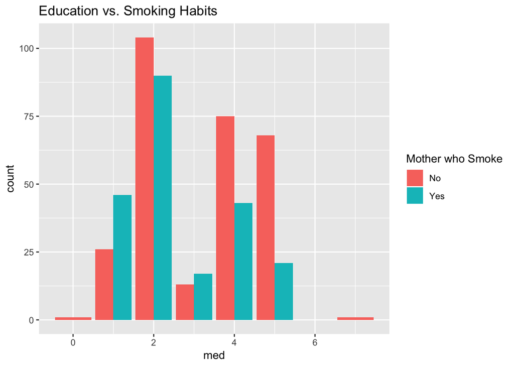

```r
babies <-na.omit(babies)
ggplot(data = babies, aes(x = med, fill = as.factor(smoke)))+
  geom_bar(position = 'dodge')+
  scale_fill_discrete(name = "Mother who Smoke",
                      labels = c('No', 'Yes'))+
  ggtitle('Education vs. Smoking Habits')
```

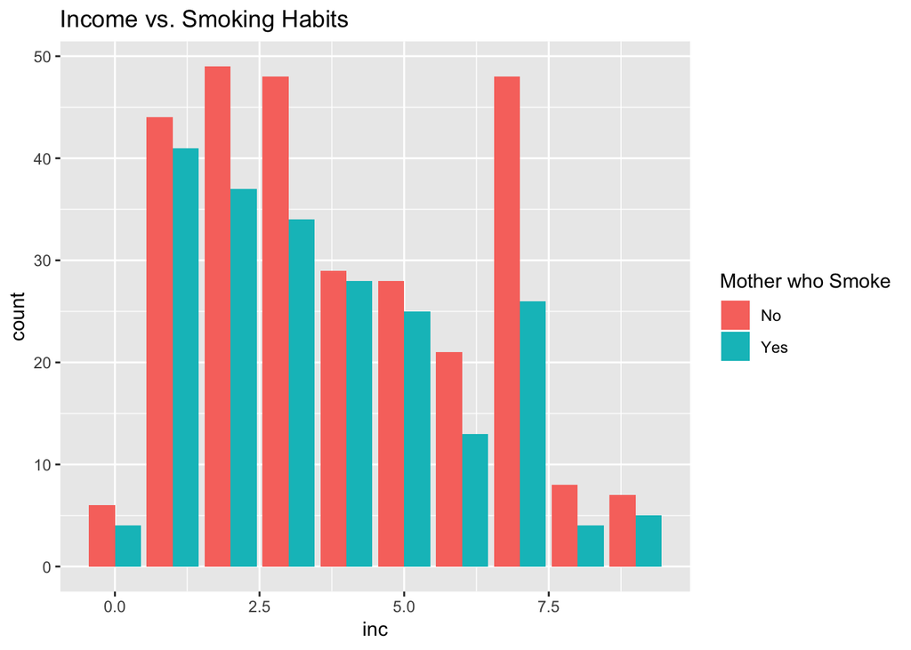

```r
ggplot(data = babies, aes(x = inc, fill = as.factor(smoke)))+
  geom_bar(position = 'dodge')+
  scale_fill_discrete(name = "Mother who Smoke",
                      labels = c('No', 'Yes'))+
  ggtitle('Income vs. Smoking Habits')
```

### Preliminary Question

Two of the variables that we determined had different distributions for smokers and non-smokers were the variables income and education. Based on the two bar plots where we plotted the distributions of education and income, with different colored bars for smokers and non-smokers, we can see that they are indeed a little different. Smokers tend to have less education and lower incomes than non-smokers. That could be a possible confounding variable and is something to consider.

## Individual’s Part

### Yen-Ting Shen

I, Yen-Ting Shen, made a bar chart that shows the relationship between mother’s age at termination of pregnancy, mother’s education background, and mother’s race. A question I wanted to answer is whether the education background of the mother affects the age they terminate the pregnancy, and also which race terminates the pregnancy the most. According to the plot I created, the mothers who only have a high school degree and did not attend any school after are more likely to terminate their pregnancy at the age between 20 to 25. In addition, most of the mothers who terminate their pregnancy are white and asian. I created this plot by using geom_bar function with x = mage. Furthermore since the “mrace” dataset from 0-5 are the same, TA helped me to create another column named “mrace2” which combine 0-5 and set them as 1. Then, I used aes fill=as.factor (mrace2) to make the plot more informative. The result surprised me because I thought the higher education a mother has, it is less likely that they will terminate their pregnancy. However, the higher education does not make mother to stop terminate their pregnancy, it only affects the age when they do it.

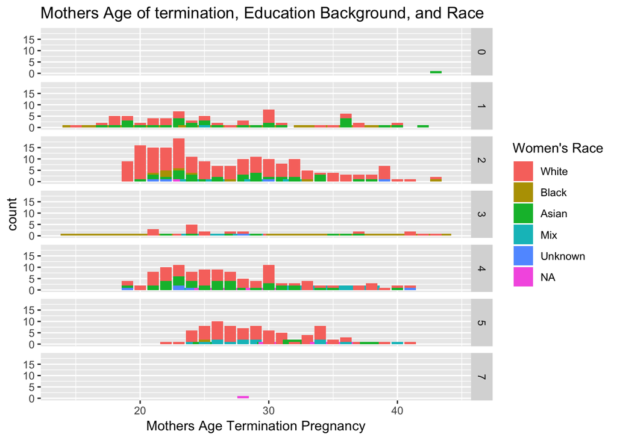

```r
babies <-na.omit(babies)
babies <- babies %>%
  mutate(mrace2 = ifelse(mrace <= 5, 1, mrace))

ggplot(data=babies)+
  geom_bar(aes(x=mage, fill=as.factor(mrace2)))+
  facet_grid(med~.)+
  scale_fill_discrete(name = "Women's Race",
                      labels = c('White', 'Black', 'Asian', 'Mix', 'Unknown'))+
  xlab('Mothers Age Termination Pregnancy')+
  ggtitle('Mothers Age of termination, Education Background, and Race')
```